# Chapter 5 Pairwise beta diversity

The diversity chapter partitions turnover across the whole panel. Here we compare every pair of the 360 samples with `hilldiv3::hillpair()`. For each pair, we use the C dissimilarity, the complement of the C overlap derived from multiplicative Hill beta diversity. It ranges from zero for identical communities to one for no overlap. We calculate neutral and phylogenetic values at $q=0$, $q=1$, and $q=2$ using the same representative profiles and tree as above. Each type and order has 64,620 unique sample pairs.

The two `hillpair()` calls return one row per sample pair and order. We request the long-format result so the sample IDs can be joined to their habitats.

```r
pair_neutral <- hilldiv3::hillpair(
  overview_abundance, q = c(0, 1, 2), metric = "C",
  type = "neutral", out = "tibble"
)
pair_phylogenetic <- hilldiv3::hillpair(
  overview_abundance, q = c(0, 1, 2), metric = "C",
  tree = genome_tree, type = "phylogenetic", out = "tibble"
)
```

## 5.1 Within and between habitats

The table summarizes all sample pairs in each category. A habitat contributes 990 within-habitat pairs; two distinct habitats contribute 2,025 pairs. These pairs share samples, so their values are descriptive observations rather than independent replicates for a significance test.

```r
pair_summary <- do.call(rbind, lapply(
  split(pairwise, list(pairwise$type, pairwise$q,
                       pairwise$comparison), drop = TRUE),
  function(d) data.frame(
    Type = as.character(d$type[1]), q = d$q[1],
    Comparison = d$comparison[1], Pairs = nrow(d),
    Median = median(d$value),
    Q1 = unname(quantile(d$value, 0.25)),
    Q3 = unname(quantile(d$value, 0.75))
  )
))
pair_summary <- pair_summary[
  order(match(pair_summary$Type, c("Neutral", "Phylogenetic")),
        pair_summary$q,
        match(pair_summary$Comparison,
              c("Within habitat", "Between habitats"))),
]
pair_summary$`Median [IQR]` <- sprintf(
  "%.3f [%.3f–%.3f]", pair_summary$Median,
  pair_summary$Q1, pair_summary$Q3
)
knitr::kable(pair_summary[c("Type", "q", "Comparison", "Pairs",
                            "Median [IQR]")], row.names = FALSE)
```

| Type | q | Comparison | Pairs | Median [IQR] |
| --- | --- | --- | --- | --- |
| Neutral | 0 | Within habitat | 7920 | 0.714 [0.484–0.898] |
| Neutral | 0 | Between habitats | 56700 | 0.992 [0.872–1.000] |
| Neutral | 1 | Within habitat | 7920 | 0.748 [0.527–0.923] |
| Neutral | 1 | Between habitats | 56700 | 0.999 [0.902–1.000] |
| Neutral | 2 | Within habitat | 7920 | 0.842 [0.639–0.971] |
| Neutral | 2 | Between habitats | 56700 | 1.000 [0.950–1.000] |
| Phylogenetic | 0 | Within habitat | 7920 | 0.438 [0.297–0.576] |
| Phylogenetic | 0 | Between habitats | 56700 | 0.758 [0.570–0.843] |
| Phylogenetic | 1 | Within habitat | 7920 | 0.183 [0.115–0.285] |
| Phylogenetic | 1 | Between habitats | 56700 | 0.454 [0.258–0.545] |
| Phylogenetic | 2 | Within habitat | 7920 | 0.085 [0.043–0.155] |
| Phylogenetic | 2 | Between habitats | 56700 | 0.217 [0.124–0.300] |

*C dissimilarity for all unique sample pairs, summarized as median [interquartile range]. Each within-habitat row contains eight sets of 990 pairs; each between-habitat row contains 28 sets of 2,025 pairs.*

At $q=1$, neutral C dissimilarity has median 0.748 within habitats and 0.999 between habitats.

At $q=1$, phylogenetic C dissimilarity has median 0.183 within habitats and 0.454 between habitats.

Neutral between-habitat medians are close to one at every order, including $q=2$, where common representatives carry the most weight. Phylogenetic between-habitat medians decrease from $q=0$ to $q=2$, consistent with greater shared branch structure among the more abundant representatives.

## 5.2 Habitat pair comparisons

We take the median across the sample pairs for each pair of habitats. A diagonal cell summarizes pairs of *different samples* from the same habitat; it is not a self-comparison. The heatmaps show $q=1$, with a common zero-to-one colour scale for both diversity types.

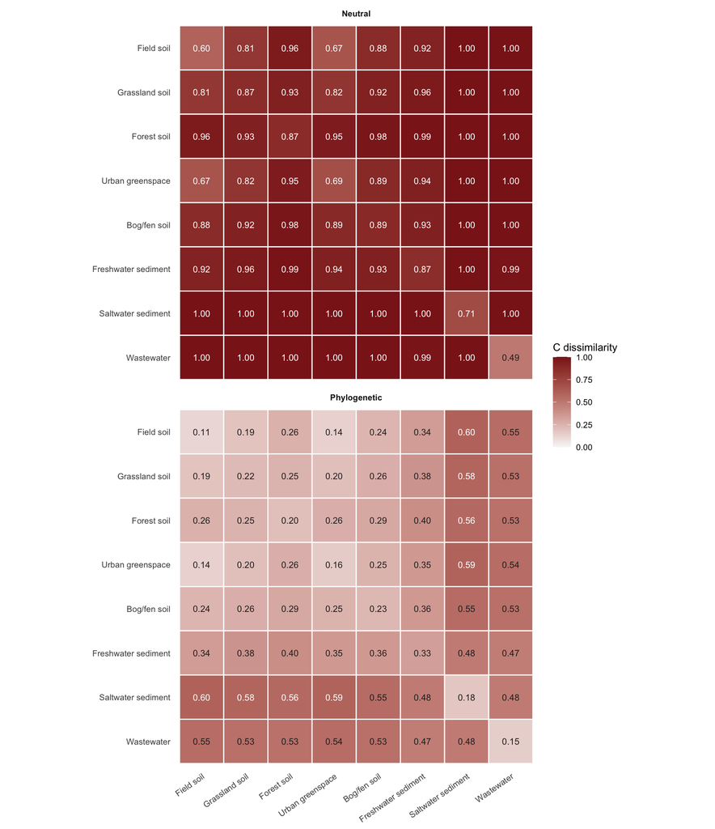

```r
ggplot2::ggplot(heatmap_data,
                ggplot2::aes(x = Habitat2, y = Habitat1, fill = median)) +
  ggplot2::geom_tile(colour = "white", linewidth = 0.5) +
  ggplot2::geom_text(ggplot2::aes(label = sprintf("%.2f", median),
                                 colour = median > 0.55), size = 3) +
  ggplot2::scale_colour_manual(values = c(`FALSE` = "#292929",
                                          `TRUE` = "white"), guide = "none") +
  ggplot2::scale_fill_gradient(low = "#f7f7f7", high = "#8b1e1e",
                               limits = c(0, 1), name = "C dissimilarity") +
  ggplot2::facet_wrap(~ type, ncol = 1) +
  ggplot2::coord_equal() +
  ggplot2::labs(x = NULL, y = NULL) +
  ggplot2::theme_minimal(base_size = 10) +
  ggplot2::theme(panel.grid = ggplot2::element_blank(),
                 axis.text.x = ggplot2::element_text(angle = 35, hjust = 1),
                 strip.text = ggplot2::element_text(face = "bold"))
```

*Median $q=1$ C dissimilarity across 990 pairs on each diagonal and 2,025 pairs in each off-diagonal habitat combination. The matrices are symmetric.*

Saltwater sediment and wastewater are nearly maximally dissimilar to the soil habitats at $q=1$ in the neutral analysis. Their phylogenetic dissimilarities are lower, showing that the sample pairs retain some shared evolutionary branch structure despite little overlap in representative profiles.

## 5.3 Sample-level ordination

Principal coordinates analysis (PCoA) projects the $q=0$ and $q=1$ dissimilarities into two dimensions. At $q=0$, neutral dissimilarity reflects overlap among detected representatives; phylogenetic dissimilarity also accounts for their shared tree branches. We apply a Cailliez correction because C dissimilarity need not be Euclidean. Axis percentages refer to the corrected distance matrix in each panel.

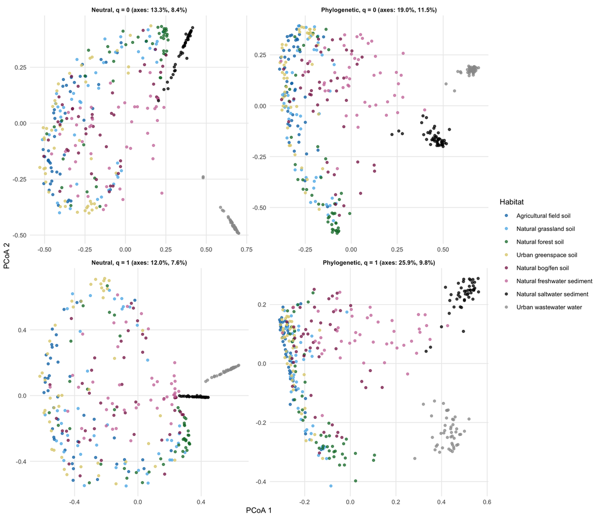

```r
ggplot2::ggplot(ordination,
                ggplot2::aes(x = PCoA1, y = PCoA2, colour = habitat)) +
  ggplot2::geom_point(alpha = 0.75, size = 1.3) +
  ggplot2::scale_colour_manual(values = habitat_colours) +
  ggplot2::facet_wrap(~ panel, ncol = 2, scales = "free") +
  ggplot2::labs(x = "PCoA 1", y = "PCoA 2", colour = "Habitat") +
  ggplot2::theme_minimal(base_size = 10) +
  ggplot2::theme(panel.grid.minor = ggplot2::element_blank(),
                 strip.text = ggplot2::element_text(face = "bold"))
```

*Each point is one sample. The top row shows richness-based $q=0$ dissimilarity; the bottom row shows abundance-weighted $q=1$ dissimilarity. Axis percentages are the shares of positive eigenvalues after the Cailliez correction; coordinates are comparable only within a panel.*

The pairwise patterns describe this selected panel. Pairs sharing samples are dependent, and habitat class is partly confounded with sampling year. We do not treat visual separation or differences between pairwise medians as a formal test of a habitat effect. As elsewhere, $q=0$ responds to very small reported abundances in the source profiles.